# PCA and Linear Regression. t-SNE and UMAP

Y. Burankova

# 0. Install requires packages

- **dplyr** 1.0.5, for data manipulation.
- **ggplot2** 3.3.5 for plotting.
- **gridExtra** 2.3 for plotting.
- **caTools** 1.18.2 for test and train split.
- **vegan** 2.5.7 for PCA.
- **caret** 6.0.90 for data scaling.
- **kernlab** 0.9.29 for kernel PCA.
- **Seurat** 4.0.5 for t-SNE and UMAP plotting.

# 1. Dowload file and unpack files

Downloading, unpacking and combining these files into one table (without “material” column). Also, delete columns with all zeros.

After this process we get new data frame - new_table (dimensions - 21263, 159).

# 2. Divide the data into training and test samples

```r
require(caTools)
set.seed(42)
sample = sample.split(new_table$critical_temp, SplitRatio = .75)
train = subset(new_table, sample == TRUE)
test  = subset(new_table, sample == FALSE)
```

# 3. Normalize the train and test data

```r
norm.train <- train
temp <- scale(train[, -1])
norm.train[, -1] <- temp

normParam <- preProcess(train[, -1])
norm.test <- predict(normParam, test)
```

# 4. Linear model with all columns

```r
model <- lm(critical_temp ~ ., data = norm.train)
model_summary <- summary(model)
```

Residual standard error: 16.5 on 16177 degrees of freedom

Multiple R-squared: 0.769096, Adjusted R-squared: 0.766841.

F-statistic: 341 on 158 and 16177 DF, p-value: <2e-16.

MAE = 12.613917.

The model contains too many predictors, so it might be better.

# 5. PCA

Run principal components analysis on all train set.

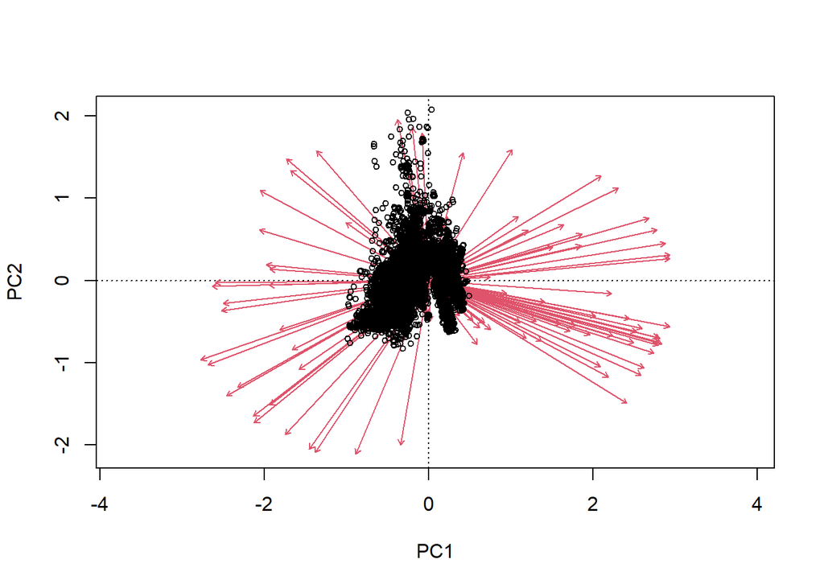

There are 158 principal components.

Let’s analyze the results using the eigenvalue plot:

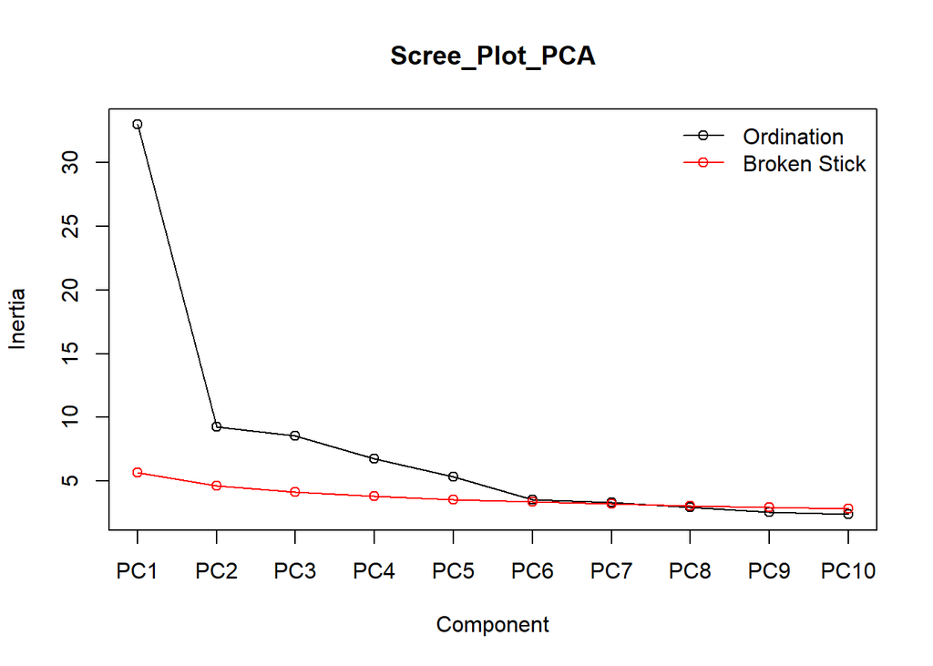

You can see that there are maybe enough 7 principal components.

The Cumulative Proportion from summary:

|  | Cumulative Proportion | component |
| --- | --- | --- |
| importance.PC67 | 0.909817 | importance.PC67 |

90% of the variability can be explained by 67 main components. Let’s try to apply both of these options to building a linear model.

## 5.1. Getting Principal Component Scores and Data Transformation

### 5.1.1. 7 principal components

Getting Principal Component Scores.

```r
pca_scores_7 <- as.data.frame(scores(temp_pca_train, display = "species",
                     choices = c(1:7), scaling = 0))
```

#### Train data transformation

```r
matrix_mult_train_7 <- function (pca_scores_7)  {
  as.matrix(norm.train[, -1]) %*% pca_scores_7
}

pca_train_7 <- as.data.frame(apply(pca_scores_7, 2, matrix_mult_train_7))
pca_train_7 <- cbind(critical_temp=norm.train[, 1], pca_train_7)
```

#### Test data transformation

```r
matrix_mult_test_7 <- function (pca_scores_7)  {
  as.matrix(norm.test[, -c(1, 160)]) %*% pca_scores_7
}

pca_test_7 <- as.data.frame(apply(pca_scores_7, 2, matrix_mult_test_7))
pca_test_7 <- cbind(critical_temp=norm.test[, 1], pca_test_7)
```

### 5.1.2. 67 principal components

Getting Principal Component Scores and do the same data transormation.

## 5.2. New linear regression after PCA

### 5.2.1. With 7 principal component

```
##
## Call:
## lm(formula = critical_temp ~ ., data = pca_train_7)
##
## Residuals:
##    Min     1Q Median     3Q    Max
## -97.62 -15.59   0.13  14.14 201.85
##
## Coefficients:
##             Estimate Std. Error t value Pr(>|t|)
## (Intercept)  34.4193     0.1737   198.2   <2e-16 ***
## PC1           4.0159     0.0302   132.8   <2e-16 ***
## PC2          -1.9397     0.0571   -33.9   <2e-16 ***
## PC3           2.4256     0.0594    40.8   <2e-16 ***
## PC4           1.3070     0.0667    19.6   <2e-16 ***
## PC5           2.2993     0.0753    30.6   <2e-16 ***
## PC6          -2.9488     0.0924   -31.9   <2e-16 ***
## PC7           1.1917     0.0952    12.5   <2e-16 ***
## ---
## Signif. codes:
## 0 '***' 0.001 '**' 0.01 '*' 0.05 '.' 0.1 ' ' 1
##
## Residual standard error: 22.2 on 16328 degrees of freedom
## Multiple R-squared:  0.584,  Adjusted R-squared:  0.584
## F-statistic: 3.28e+03 on 7 and 16328 DF,  p-value: <2e-16
```

R-squared: 0.584277, Adjusted R-squared: 0.584099.

(without PCA it was multiple R-squared: 0.769096, adjusted R-squared: 0.766841.)

MAE = 17.310695.

According to the R-squared and MAE, the model became worse. Presumably because the 7 principal components explain much less than 90% of the variance.

### 5.2.2. With 67 principal component

```
##
## Call:
## lm(formula = critical_temp ~ ., data = pca_train_67)
##
## Residuals:
##     Min      1Q  Median      3Q     Max
## -201.22  -11.14   -0.38   11.77  197.87
##
## Coefficients:
##             Estimate Std. Error t value Pr(>|t|)
## (Intercept)  34.4193     0.1552  221.72  < 2e-16 ***
## PC1           4.0159     0.0270  148.59  < 2e-16 ***
## PC2          -1.9397     0.0511  -37.98  < 2e-16 ***
## PC3           2.4256     0.0531   45.69  < 2e-16 ***
## PC4           1.3070     0.0596   21.92  < 2e-16 ***
## PC5           2.2993     0.0673   34.19  < 2e-16 ***
## PC6          -2.9488     0.0825  -35.73  < 2e-16 ***
## PC7           1.1917     0.0851   14.00  < 2e-16 ***
## PC8           0.8413     0.0904    9.31  < 2e-16 ***
## PC9           0.6087     0.0973    6.26  4.1e-10 ***
## PC10          1.3682     0.1005   13.61  < 2e-16 ***
## PC11         -1.1391     0.1054  -10.81  < 2e-16 ***
## PC12          1.5376     0.1080   14.24  < 2e-16 ***
## PC13          2.4575     0.1126   21.83  < 2e-16 ***
## PC14         -3.0804     0.1148  -26.84  < 2e-16 ***
## PC15         -1.0961     0.1172   -9.35  < 2e-16 ***
## PC16         -2.0219     0.1181  -17.12  < 2e-16 ***
## PC17          0.3115     0.1190    2.62   0.0089 **
## PC18          0.9620     0.1220    7.89  3.3e-15 ***
## PC19          0.9282     0.1237    7.50  6.5e-14 ***
## PC20         -0.0475     0.1275   -0.37   0.7094
## PC21         -2.3870     0.1294  -18.45  < 2e-16 ***
## PC22         -1.0479     0.1319   -7.94  2.1e-15 ***
## PC23          0.6037     0.1335    4.52  6.2e-06 ***
## PC24         -0.2415     0.1351   -1.79   0.0739 .
## PC25         -0.0550     0.1375   -0.40   0.6890
## PC26          1.2252     0.1387    8.83  < 2e-16 ***
## PC27          0.7441     0.1389    5.36  8.6e-08 ***
## PC28          1.1378     0.1403    8.11  5.5e-16 ***
## PC29          0.2199     0.1427    1.54   0.1235
```

[output cut: 30 more lines]

```
## PC60         -1.0696     0.1665   -6.42  1.4e-10 ***
## PC61          0.8467     0.1683    5.03  4.9e-07 ***
## PC62          0.0994     0.1702    0.58   0.5590
## PC63          0.6733     0.1727    3.90  9.7e-05 ***
## PC64          1.3677     0.1736    7.88  3.5e-15 ***
## PC65         -1.0865     0.1772   -6.13  9.0e-10 ***
## PC66         -1.2268     0.1782   -6.89  6.0e-12 ***
## PC67          0.8870     0.1808    4.91  9.4e-07 ***
## ---
## Signif. codes:
## 0 '***' 0.001 '**' 0.01 '*' 0.05 '.' 0.1 ' ' 1
##
## Residual standard error: 19.8 on 16268 degrees of freedom
## Multiple R-squared:  0.669,  Adjusted R-squared:  0.668
## F-statistic:  491 on 67 and 16268 DF,  p-value: <2e-16
```

R-squared: 0.669161, Adjusted R-squared: 0.667799 (without PCA it were R-squared: 0.769096, adjusted R-squared: 0.766841).

MAE = 14.749. According to the R-squared, the model became a bit worse, and the MAE has grown too. However, the 67 principal component model is better than the 7 principal component model.

### 5.2.3. With 53 principal component

However, the influence of not all major principal is significant. Let’s try to reduce the number of principal components, leaving only significant ones.

```
##
## Call:
## lm(formula = critical_temp ~ ., data = data_select_train)
##
## Residuals:
##     Min      1Q  Median      3Q     Max
## -201.41  -11.03   -0.41   11.81  197.34
##
## Coefficients:
##             Estimate Std. Error t value Pr(>|t|)
## (Intercept)  34.4193     0.1552  221.74  < 2e-16 ***
## PC1           4.0159     0.0270  148.60  < 2e-16 ***
## PC2          -1.9397     0.0511  -37.98  < 2e-16 ***
## PC3           2.4256     0.0531   45.69  < 2e-16 ***
## PC4           1.3070     0.0596   21.92  < 2e-16 ***
## PC5           2.2993     0.0673   34.19  < 2e-16 ***
## PC6          -2.9488     0.0825  -35.73  < 2e-16 ***
## PC7           1.1917     0.0851   14.00  < 2e-16 ***
## PC8           0.8413     0.0903    9.31  < 2e-16 ***
## PC9           0.6087     0.0973    6.26  4.0e-10 ***
## PC10          1.3682     0.1005   13.61  < 2e-16 ***
## PC11         -1.1391     0.1054  -10.81  < 2e-16 ***
## PC12          1.5376     0.1080   14.24  < 2e-16 ***
## PC13          2.4575     0.1126   21.83  < 2e-16 ***
## PC14         -3.0804     0.1148  -26.84  < 2e-16 ***
## PC15         -1.0961     0.1172   -9.35  < 2e-16 ***
## PC16         -2.0219     0.1181  -17.13  < 2e-16 ***
## PC17          0.3115     0.1190    2.62   0.0089 **
## PC18          0.9620     0.1220    7.89  3.3e-15 ***
## PC19          0.9282     0.1237    7.51  6.4e-14 ***
## PC21         -2.3870     0.1294  -18.45  < 2e-16 ***
## PC22         -1.0479     0.1319   -7.94  2.1e-15 ***
## PC23          0.6037     0.1335    4.52  6.2e-06 ***
## PC26          1.2252     0.1387    8.84  < 2e-16 ***
## PC27          0.7441     0.1389    5.36  8.5e-08 ***
## PC28          1.1378     0.1403    8.11  5.5e-16 ***
## PC31          0.8400     0.1457    5.77  8.2e-09 ***
## PC32         -0.7665     0.1466   -5.23  1.7e-07 ***
## PC33         -1.0186     0.1481   -6.88  6.3e-12 ***
## PC34          1.7572     0.1493   11.77  < 2e-16 ***
```

[output cut: 16 more lines]

```
## PC58          1.0013     0.1650    6.07  1.3e-09 ***
## PC60         -1.0696     0.1665   -6.43  1.4e-10 ***
## PC61          0.8467     0.1683    5.03  4.9e-07 ***
## PC63          0.6733     0.1727    3.90  9.7e-05 ***
## PC64          1.3677     0.1736    7.88  3.5e-15 ***
## PC65         -1.0865     0.1772   -6.13  9.0e-10 ***
## PC66         -1.2268     0.1782   -6.89  5.9e-12 ***
## PC67          0.8870     0.1808    4.91  9.3e-07 ***
## ---
## Signif. codes:
## 0 '***' 0.001 '**' 0.01 '*' 0.05 '.' 0.1 ' ' 1
##
## Residual standard error: 19.8 on 16282 degrees of freedom
## Multiple R-squared:  0.669,  Adjusted R-squared:  0.668
## F-statistic:  621 on 53 and 16282 DF,  p-value: <2e-16
```

MAE = 14.744987.

R-squared: 0.66893, Adjusted R-squared: 0.667852.

(without PCA it were R-squared: 0.769096, adjusted R-squared: 0.766841, with 67 PC - R-squared: 0.669161, Adjusted R-squared: 0.667799).

So it didn’t make our model much better.

# 6. Principal Component Regression (PCR)

We use a library that combines principal component analysis with linear regression. For prediction, we use 67 principal components, as in the second PCA case.

```
## Data:    X dimension: 16336 158
##  Y dimension: 16336 1
## Fit method: svdpc
## Number of components considered: 158
##
## VALIDATION: RMSEP
## Cross-validated using 10 random segments.
##        (Intercept)  1 comps  2 comps  3 comps  4 comps
## CV           34.43    25.56    24.88    23.86    23.61
## adjCV        34.43    25.56    24.88    23.86    23.61
##        5 comps  6 comps  7 comps  8 comps  9 comps
## CV          23    22.41    22.27    22.24    22.21
## adjCV       23    22.40    22.27    22.23    22.20
##        10 comps  11 comps  12 comps  13 comps  14 comps
## CV        22.09     22.03     22.08     22.07     22.26
## adjCV     22.09     22.02     22.06     22.00     22.13
##        15 comps  16 comps  17 comps  18 comps  19 comps
## CV        22.59     22.36     22.27     22.30     22.32
## adjCV     22.45     22.19     22.14     22.17     22.19
##        20 comps  21 comps  22 comps  23 comps  24 comps
## CV        22.20     21.48     21.29     21.31     21.30
## adjCV     22.08     21.41     21.23     21.25     21.24
##        25 comps  26 comps  27 comps  28 comps  29 comps
## CV        21.29     21.32     21.51     21.61     21.43
## adjCV     21.24     21.25     21.42     21.51     21.35
##        30 comps  31 comps  32 comps  33 comps  34 comps
## CV        21.45     21.94     23.64     25.02     26.42
## adjCV     21.37     21.82     23.37     24.63     25.89
##        35 comps  36 comps  37 comps  38 comps  39 comps
## CV        26.91     28.61     29.17     27.36     26.92
## adjCV     26.35     27.88     28.40     26.73     26.33
##        40 comps  41 comps  42 comps  43 comps  44 comps
## CV        26.34     25.68     25.63     26.11     26.21
## adjCV     25.81     25.21     25.16     25.60     25.68
##        45 comps  46 comps  47 comps  48 comps  49 comps
## CV        26.25     25.61     25.73     25.98     25.62
## adjCV     25.72     25.15     25.24     25.48     25.15
##        50 comps  51 comps  52 comps  53 comps  54 comps
## CV        26.71     27.37     28.08     28.67     28.68
## adjCV     26.16     26.75     27.38     27.94     27.95
```

[output cut: 176 more lines]

```
##                139 comps  140 comps  141 comps  142 comps
## X                  99.98      99.99      99.99      99.99
## critical_temp      76.06      76.06      76.10      76.22
##                143 comps  144 comps  145 comps  146 comps
## X                  99.99      99.99      99.99     100.00
## critical_temp      76.23      76.33      76.59      76.59
##                147 comps  148 comps  149 comps  150 comps
## X                 100.00     100.00     100.00     100.00
## critical_temp      76.61      76.61      76.62      76.67
##                151 comps  152 comps  153 comps  154 comps
## X                  100.0     100.00     100.00     100.00
## critical_temp       76.7      76.72      76.81      76.83
##                155 comps  156 comps  157 comps  158 comps
## X                 100.00      100.0     100.00     100.00
## critical_temp      76.83       76.9      76.91      76.91
```

MAE = 14.834, but R-squared is 0.6692. The result is similar to what we got in two steps (combining pca and lm).

# 7. Using the kernel PCA

Kernel Principal Components Analysis is a nonlinear form of principal component analysis.

**!Warning!** The process takes at least an hour and requires more than 12 GB of RAM. If there is less RAM available, do this step in Python! Scipt in `kernel_PCA_python.ipynb`.

Run a Kernel PCA on data, we have used all available principal components.

```r
kpca <-  kpca(~., data = norm.train[, -1], kernel = 'rbfdot')
```

Transform the data using the calculated principal components.

```r
norm.train.kpca <- as.data.frame(predict(kpca, norm.train[,-1]))
norm.train.kpca$critical_temp <- norm.train$critical_temp

norm.test.kpca <-  as.data.frame(predict(kpca, norm.test[,-1]))
norm.test.kpca$critical_temp <- norm.test$critical_temp
```

Linear regression on the transformed data:

```r
lm_kpca <- lm(formula = critical_temp ~ .,
              family = gaussian,
              data = norm.train.kpca)
```

Run results (08.12.2021):

- **Residual standard error**: 12.86 on 14564 degrees of freedom.
- Multiple R-squared: **0.8755**, Adjusted R-squared: **0.8604**.
- F-statistic: 57.85 on 1771 and 14564 DF, p-value: < 2.2e-16.

Much better!

```r
prob_pred <-  as.data.frame(predict(classifier,
                                    newdata  = select(norm.test.kpca,
                                                      -critical_temp)))

prob_pred$critical_temp <- norm.test$critical_temp
```

Run results (08.12.2021): MAE = 9.192386.

When running in Python: MAE = 2.70063. R-squared: 0.937, Adj. R-squared: 0.936.

Using Kernel Principal Components Analysis the model has become much better and its predictive power has improved.

# 8. sc-RNA seq data visualization

Read file. There are 8617 rows and 977 columns in the data. It is CITE-seq data, Cellular Indexing of Transcriptomes and Epitopes by Sequencing, in which was simultaneously measured the single cell transcriptomes alongside the expression of 977 proteins.

## 8.1. t-SNE - t-Distributed Stochastic Neighbor Embedding

### 8.1.1. Data Preprocessing

t-SNE is used for dimensionality reduction for the visualization of high-dimensional datasets. The last column contain the number of cluster, that we delete it before t-SNE.

Create Seurat Object:

```
## An object of class Seurat
## 8617 features across 976 samples within 1 assay
## Active assay: RNA (8617 features, 0 variable features)
```

There are 0 of transcripts mapping to mitochondrial genes.

Basic data information for quality control - Scatter plot of nCount_RNA and nFeature_RNA:

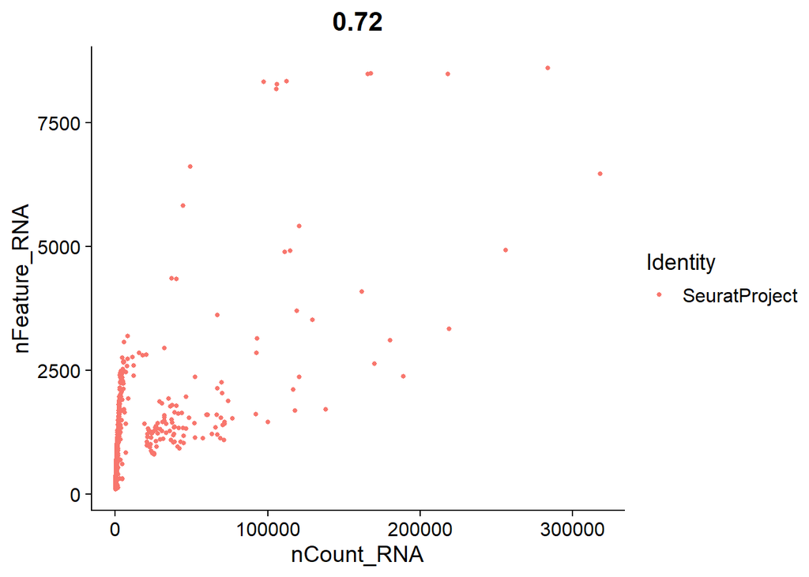

```r
RNA_seurat <- subset(RNA_seurat, subset = nFeature_RNA > 200  & nCount_RNA < 60000)
```

Normalized the data with function LogNormalize and Identify of Highly Variable Features.

Cell-to-cell variation of each feature, with each red point represents a highly variable feature:

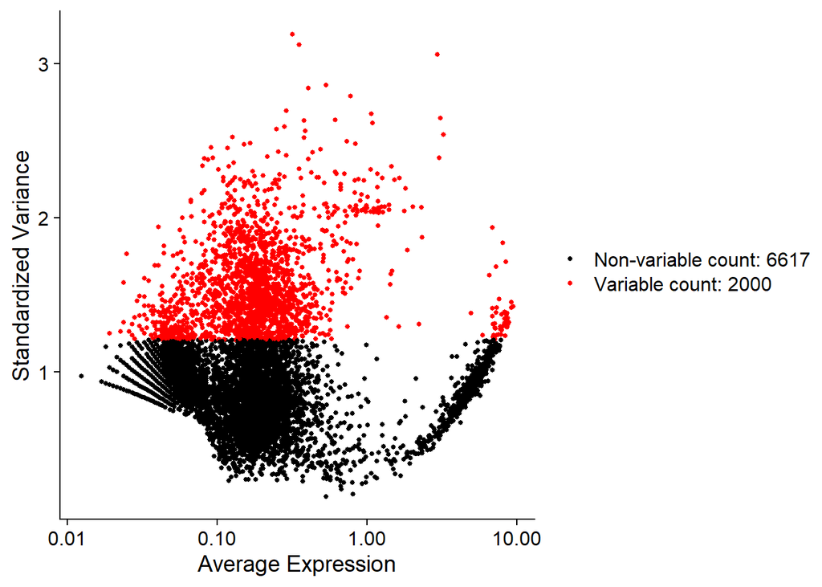

```r
RNA_seurat <- NormalizeData(RNA_seurat)

RNA_seurat <- FindVariableFeatures(RNA_seurat)

VariableFeaturePlot(RNA_seurat)
```

Scaling makes each gene equal weight, thus highly expressed genes do not dominate in later analyses (function ScaleData that scales the mean and variance of each feature across cells is 0 and 1).

```r
RNA_seurat <- ScaleData(RNA_seurat, features = rownames(RNA_seurat))
```

### 8.1.2. Visualization of scRNA-seq Data Using t-SNE

Run PCA on the scaled data, returning 50 PCs (default):

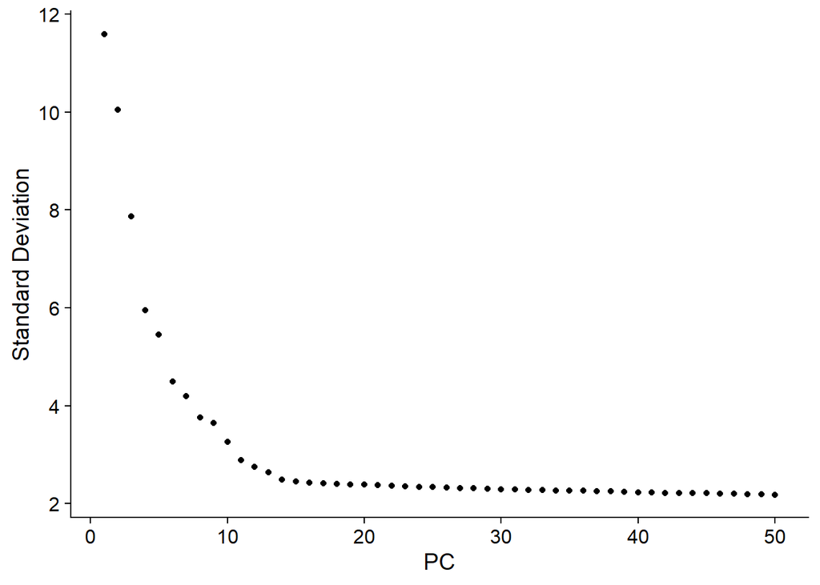

```r
ElbowPlot(RNA_seurat, ndims = 50)
```

Cluster cells into different groups based on their expression pattern to investigate cell properties. Cluster cells using FindNeighbors and FindClusters function (using 20 PCs):

```r
RNA_seurat <- FindNeighbors(RNA_seurat, dims = 1:20)
```

```r
RNA_seurat <- FindClusters(RNA_seurat, resolution = 1)
```

```
## Modularity Optimizer version 1.3.0 by Ludo Waltman and Nees Jan van Eck
##
## Number of nodes: 887
## Number of edges: 31857
##
## Running Louvain algorithm...
## Maximum modularity in 10 random starts: 0.7026
## Number of communities: 9
## Elapsed time: 0 seconds
```

Visualize scRNA-seq data by running RunTSNE function, with the same PCs as input for the cell clustering:

```r
RNA_seurat <- RunTSNE(RNA_seurat, dims = 1:20, tsne.method = "Rtsne")
```

Visualization of Single Cell RNA-seq Data Using PCA. Each pair of color and number indicates an inferred cluster:

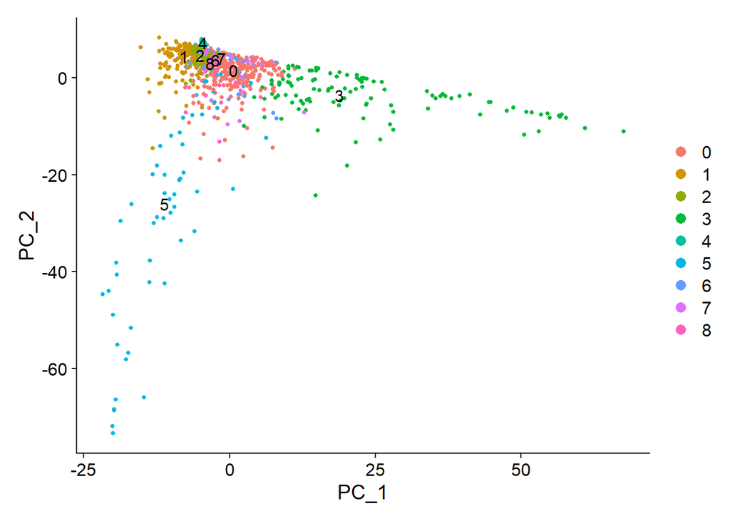

Visualization of Single Cell RNA-seq Data Using t-SNE. Each pair of color and number indicates an inferred cluster:

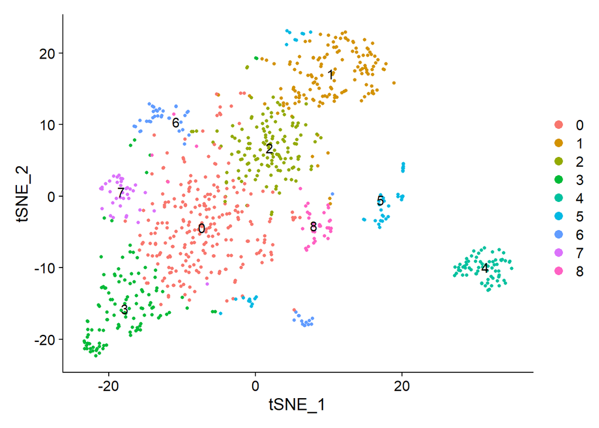

## 8.2. Visualization of scRNA-seq Data Using UMAP

UMAP is a technique that offers a number of advantages over t-SNE - increased speed and better preservation of the data’s global structure.

Use the prepared data from section 8.1.1. Run UMAP:

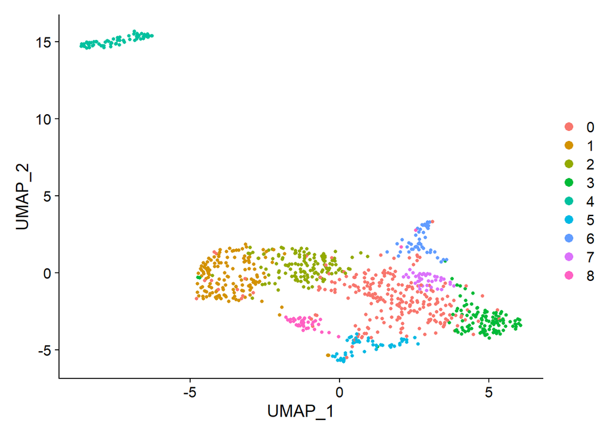

```r
RNA_seurat <- RunUMAP(RNA_seurat, dims = 1:20)

DimPlot(RNA_seurat, reduction = "umap")
```

## 8.3. t-SNE and UMAP results

Using t-SNE we identify 9 cell type populations that in our data (there were 13 clusters in initially the data).

PCA, t-SNE and UMAP both show 9 cell types.

t-SNE plot shows that one cluster is fully isolated, and other groups are partially overlapping. t-SNE separate fully overlapped clusters from PCA.

UMAP plot shows that one cluster is fully isolated, and other groups are partially overlapping. UMAP separate fully overlapped clusters from PCA. UMAP better separate clusters 5, 6 and 8 than tSNE.

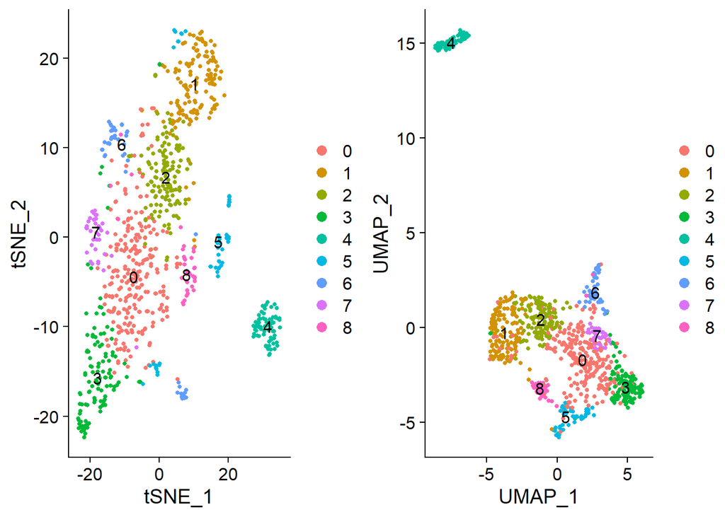